# Direct and inverse geometry of 2d robots

This notebook the main concept of kinematic tree, direct geometry and inverse geometry, but without the kinematic tree of Pinocchio. We only use the basic geometries of the our 3d viewer for displaying the simple robot that is used in this tutorial.

```python
import magic_donotload
```

```
NB: as for all the tutorials, a magic command %do_not_load is introduced to hide the solutions to some questions. Change it for %load if you want to see (and execute) the solution.
```

## Set up

We will need NumPy, SciPy, and MeshCat Viewer for vizualizing the robot. Scipy is a collection of scientific tools for Python. It contains, in particular, a set of optimizers that we are going to use for solving the inverse-geometry problem.

```python
import time
import numpy as np
from scipy.optimize import fmin_bfgs,fmin_slsqp
from utils.meshcat_viewer_wrapper import MeshcatVisualizer,translation2d,planar
from numpy.linalg import norm,inv,pinv,svd,eig
```

## Displaying objects

Let's first learn how to open a 3D viewer, in which we will build our simulator. We will use the viewer MeshCat which directly displays in a browser. Open it as follows:

```python
viz = MeshcatVisualizer()
viz.viewer.jupyter_cell()
```

```
You can open the visualizer by visiting the following URL:
http://127.0.0.1:7001/static/
```

[interactive chart not shown]

The following object is a client of the viewer, i.e. it will be use to pass display command to the viewer. The first commands are to create objects:

```python
ballID = 'world/ball'; viz.addSphere(ballID,.2,[1,0,0,1])
cylID = 'world/cyl';   viz.addCylinder(cylID,length=1,radius=.1,color=[0,0,1,1])
boxID = 'world/box';   viz.addBox(boxID,[.5,.2,.4],[1,1,0,1])
```

You can re-set objects under the same name, which will simply replace your object by another one. If you want to erase your world and all your objects, just run:

```python
viz.delete(ballID)
```

The objects can be placed at a desired pose using the applyConfiguration command, specifying displacement as list of 7 values (3 translation, 4 quaternion).

```python
viz.applyConfiguration(cylID,[.1,.2,.3,1,0,0,0])
```

It is also possible to specify poses in 2D specifying (x,y,theta) placement. An example follows:

```python
viz.applyConfiguration(boxID,planar(0.1, 0.2, np.pi / 3))
viz.applyConfiguration(cylID,planar(0.1, 0.2, 5*np.pi / 6))
```

## Creating a 2 dof robot

This robot will have:

- 2 rotating joints (that are spheres), named shoulder and elbow
- With 2 links of length 1 (that are cylinders) to connect them
- A fixed joint (also a sphere) at the output of the last link.

First, let's first remove the previous objects and create the 5 geometry objects for the robot (plus one for the target).

```python
viz.delete(ballID)
viz.delete(cylID)
viz.delete(boxID)
```

```python
viz.addSphere('joint1',.1,[1,0,0,1])
viz.addSphere('joint2',.1,[1,0,0,1])
viz.addSphere('joint3',.1,[1,0,0,1])
viz.addCylinder('arm1',.75,.05,[.65,.65,.65,1])
viz.addCylinder('arm2',.75,.05,[.65,.65,.65,1])
viz.addSphere('target',.05,[0,.8,.1,1])
```

The frame attached to each link is at the barycenter of the object.

Given a configuration vector q of dimension 2 compute the position of the centers of each object, and display correctly the robot.

First compute a random configuration vector, each variable is in $[-\pi,\pi]$:

```python
q = np.random.rand(2) * 2 * np.pi - np.pi
```

Use geometry with the right frame to compute the placement of all link given the configuration. In other words: code the forward kinematic.

[figure not shown]

```python
def display(q):
    '''Display the robot in MeschCat Viewer. '''
    assert (q.shape == (2,))

    # viz.applyConfiguration('name',planar(x,    y,    t))
    viz.applyConfiguration('joint1',planar(0,    0,    0))
    viz.applyConfiguration('arm1'  ,planar(0.5*np.cos(q[0]), 0.5*np.sin(q[0]), q[0]))
    viz.applyConfiguration('joint2',planar(np.cos(q[0]), np.sin(q[0]), q[0]))
    viz.applyConfiguration('arm2'  ,planar(np.cos(q[0])+0.5*np.cos(q[0]+q[1]), np.sin(q[0])+0.5*np.sin(q[0]+q[1]), q[0]+q[1]))
    viz.applyConfiguration('joint3',planar(np.cos(q[0])+np.cos(q[0]+q[1]), np.sin(q[0])+np.sin(q[0]+q[1]), q[0]+q[1]))
```

And here is the solution if you need it.

```python
%load tp5/generated/configuration_reduced_display
```

```python
display(q) # Display the robot in the viewer
```

The end effector (located in the center of the last sphere) is already computed in the previous method. Let's build a dedicated method to return the same value. Write a function `endeffector(q)`, which takes the 2 joints values and returns the 2d position of the robot end effector.

```python
def endeffector(q):
        x,y = np.cos(q[0]) + np.cos(q[0]+q[1]), np.sin(q[0]) + np.sin(q[0]+q[1])
        return np.array([x,y])
```

Below is the solution, should you need it.

```python
%load tp5/generated/configuration_reduced_endeffector
```

```python
endeffector(q)
```

```
array([1.07925052, 0.65885809])
```

From now, we will try to (pseudo) invert the function *endeffector*, by seeking for a configuration *q* such that the end effector reaches a given position. You can first try to reach the position (0.5;0.5) either by trial-and-error, or by manually inverting the function (in the case of such a simple robot, inverting is easy).

## Optimize the configuration

Optimization will be done with the BFGS solver of scipy, which simply takes an intial guess and a cost function. Here the cost will be the squared distance to a given target.

```python
target = np.array([.5, .5])
viz.applyConfiguration('target',translation2d(target[0],target[1]))

def cost(q):
    eff = endeffector(q)
    return norm(eff - target)**2
```

In SciPy, BFGS also accepts a callback function, that we will use to display in the viewer the current value of the decision variable.

```python
def callback(q):
    display(q)
    time.sleep(.5)
```

And that is it, let's call BFGS. Use Scipy documentation if needed

```python
qopt = fmin_bfgs(cost, q, callback=callback)
```

```
Optimization terminated successfully.
         Current function value: 0.000000
         Iterations: 7
         Function evaluations: 27
         Gradient evaluations: 9
```

And the solution if needed

```python
%load tp5/generated/configuration_reduced_optim
```

## What configuration to optimize?

It seems logical to optimize over the angles $q_1,q_2$. However, other representations of the configuration are possible. Consider for example the explicit representation that consists of the pose of each body of interest. Concretely, for the 3 spheres on our robot, we get $x,y,\theta$, for each one, so 9 parameters in total. However, these spheres cannot be arbitratily placed since their relative poses are constrained by the robot's joints. The first sphere's position is fixed and is only allowed to rotate, while the remaining two spheres's motions are constrained in 2 dimensions by the previous joint. The last joint, being a fixed joint is additionally not allowed to rotate. Therefore, there are 7 and $9-7=2$ degrees of freedom.

What are the pros and cons of this representation ?

- (+) The end effector position is now a trivial function of the representation, hence the cost function is very simple.
- (-) The number of variables is higher
- (-) The trade-off is that we have to explicitly satisfy the constraints.

Let's start by defining the configuration.

```python
x1, y1, th1, x2, y2, th2, x3, y3, th3 = q0 = np.zeros(9)
```

[figure not shown]

### From configuration to cartesian positions

An advantage of the extended configuration is that the mapping from configuration to cartesian positions is typically much more straightforward. For example, the end-effector position is now ... just the last part of the configuration vector:

```python
def endeffector_9(ps):
    assert (ps.shape == (9, ))
    x1, y1, t1, x2, y2, t2, x3, y3, t3 = ps
    return np.array([x3, y3])
```

We can similarly redefined the display function, where each body is directly placed depending on the corresponding part of the configuration.

```python
def display_9(ps):
    '''Display the robot in Gepetto Viewer. '''
    assert (ps.shape == (9, ))
    x1, y1, t1, x2, y2, t2, x3, y3, t3 = ps
    viz.applyConfiguration('joint1',planar(x1,  y1,  t1))
    viz.applyConfiguration('arm1'  ,planar(x1 + 0.5*np.cos(t1), y1 + 0.5*np.sin(t1), t1))
    viz.applyConfiguration('joint2',planar(x2,  y2,  t2))
    viz.applyConfiguration('arm2'  ,planar(x2 + 0.5*np.cos(t2), y2 + 0.5*np.sin(t2), t2))
    viz.applyConfiguration('joint3',planar(x3,  y3,  t3))
```

Here is the solution, should you need it:

```python
%load tp5/generated/configuration_extended_display
```

If defining a task to reach a target, like in the previous section, the cost function is also immediate to write.

```python
def cost_9(ps):
    eff = endeffector_9(ps)
    return norm(eff - target)**2
```

### Working under constraints

But, now, a random configuration vector is likely not a valid one. Let's try: sample a random vector and display it! The result is not satisfactory.

```python
qrand9 = np.random.rand(9)
display_9(qrand9)
```

Any vector $ps$ needs to respect a set of algebraic constraints to represent a robot configuration. Let's write these constraints, as a map from the configuration space to a vector, which should be 0 when the constraints are satisfied. Our robot example has 7 constraints, so fill in the function below to return a 7d vector.

```python
def constraint_9(ps):
    constraints = np.zeros(7)
    x1, y1, t1, x2, y2, t2, x3, y3, t3 = ps
    # First joint at origin
    constraints[0] = x1
    constraints[1] = y1

    # Arm constraints (for length 1)
    constraints[2] = x2 - (x1 + np.cos(t1))
    constraints[3] = y2 - (y1 + np.sin(t1))
    constraints[4] = x3 - (x2 + np.cos(t2))
    constraints[5] = y3 - (y2 + np.sin(t2))

    # Fixed joint at the end
    constraints[6] = t3 - t2
    return constraints
```

As usual, here is the solution, should you need it.

```python
%load tp5/generated/configuration_extended_constraint
```

For example, the configuration with the 9-vector set to 0 is not satisfying the constraints.

```python
print(cost_9(q0), constraint_9(q0))
```

```
0.5000000000000001 [ 0.  0. -1.  0. -1.  0.  0.]
```

We also introduce a callback function which displays the candidate configuration in the viewer.

```python
def callback_9(ps):
    display_9(ps)
    time.sleep(.5)
```

### Solve with a penalty cost

The BFGS solver defined above cannot be used directly to optimize over equality constraints. An approximate approach is to add the constraint as a quadratic penalty, i.e. a high-weight term in the cost function: $penalty(x) = cost(x) + 10*||constraint(x)||^2$ . Here, we are in a good case where the optimum corresponds to the 0 of both the constraint and the cost. The penalty with any weight would lead to the optimum and perfect constraint satisfaction. Yet the solver finds it difficult to reach the optimum, because of the way we have described the constraint.

Define a new function *penalty*, corresponding to the previous cost function plus a huge weight multiplying the (squared) norm of the constraint.

```python
def penalty(ps):
    return  cost_9(ps) + 10 * norm(constraint_9(ps))**2
```

And the solution:

```python
%load tp5/generated/configuration_extended_penalty
```

```python
qopt = fmin_bfgs(penalty, q0, callback=callback_9)
```

```
Optimization terminated successfully.
         Current function value: 0.000000
         Iterations: 35
         Function evaluations: 430
         Gradient evaluations: 43
```

### Solve with a constrained solver

Alternatively, the solver S-LS-QP (sequential least-square quadratic-program) optimizes over equality constraints.

```python
qopt = fmin_slsqp(cost_9, q0, callback=callback_9, f_eqcons=constraint_9, iprint=2, full_output=1)[0]
```

```
  NIT    FC           OBJFUN            GNORM
    1    11     2.250000E+00     1.414214E+00
    2    21     1.937259E+00     3.000000E+00
    3    31     2.001991E+00     2.783709E+00
    4    42     1.871897E+00     2.719952E+00
    5    53     1.764294E+00     2.672066E+00
    6    64     2.678446E+00     2.633901E+00
    7    75     9.963687E+01     2.615278E+00
    8    87     1.565139E+00     2.598603E+00
    9    97     2.044357E+00     2.502110E+00
   10   108     1.572175E+00     2.465375E+00
   11   119     1.407621E+00     2.410663E+00
   12   130     1.256766E+00     2.341701E+00
   13   140     1.151803E+00     2.242112E+00
   14   150     7.797387E-01     2.146442E+00
```

[output cut: 16 more lines]

## Modeling complex kinematics

A side effect of working with extended configurations is that more complex constraints can also be taken into account by the same way. This is particularly useful to model close-kinematic chains, that we will investigate in more details in the next notebook.

Here is an example of a complex kinematics: the human foremarm is composed of two main bonex, wich enable sophisticated wrist rotations.

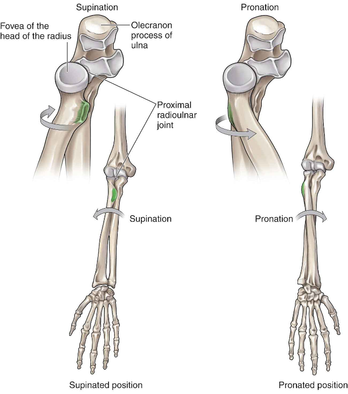

From https://musculoskeletalkey.com/elbow-10/

Proper mechanical models of this bones and joints involve close-kinematic constraints, see for example the explicit schema below.

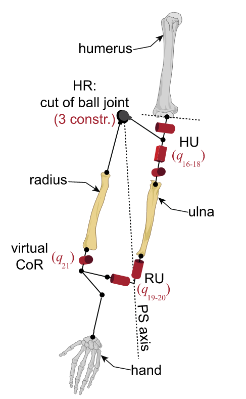

From (Laitenberger, M., Raison, M., Périé, D., & Begon, M. (2015). Refinement of the upper limb joint kinematics and dynamics using a subject-specific closed-loop forearm model. Multibody System Dynamics, 33(4), 413-438).

This can be seen as a more sophisticated version of the classical *parallelogram* structure, which enables stiff linkages of light R2 robots, has depicted below:

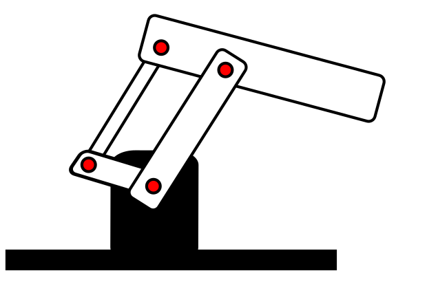

This robot has 4 moving links, with 4 joints, enabling a total of 2 degrees of freedom. It can be reprented with an extended configuration of dimension 12 (x,y,theta of each center of rotation).

**Implement the display and constraint functions, allow to optimize and visualize the search for a configuration where the end-effector of the R2 robot reaches an arbitrary 2d target.**

You can view it as two double pendulum and add a constraint or verify the geometric properties we have !

```python
viz = MeshcatVisualizer()
viz.viewer.jupyter_cell()
```

```
You can open the visualizer by visiting the following URL:
http://127.0.0.1:7002/static/
```

[interactive chart not shown]

```python
# Parameters: lengths of each link and minimum distance between elbows
L = [0.8, 1.2, 0.9, 1.1]
l = [x / 2.0 for x in L]

min_elbow_dist = 0.2

# Add Links, joints and target to vizualizer
viz.addCylinder('link1', L[0], 0.05, [0.6, 0.6, 0.6, 1])
viz.addCylinder('link2', L[1], 0.05, [0.6, 0.6, 0.6, 1])
viz.addCylinder('link3', L[2], 0.05, [0.6, 0.6, 0.6, 1])
viz.addCylinder('link4', L[3], 0.05, [0.6, 0.6, 0.6, 1])

viz.addSphere('base_joint', 0.1, [1, 0, 0, 1])
viz.addSphere('elbow_left', 0.1, [0, 1, 0, 1])
viz.addSphere('elbow_right', 0.1, [0, 1, 0, 1])
viz.addSphere('end_effector', 0.1, [0, 0, 1, 1])

target = np.array([0.5, 1.5])
viz.addSphere('target', 0.1, [1, 0, 0, 1])
viz.applyConfiguration('target', translation2d(target[0], target[1]))
```

```python
def display_12(ps):
    # Update links
    viz.applyConfiguration('link1', planar(ps[0], ps[1], ps[2]))
    viz.applyConfiguration('link2', planar(ps[3], ps[4], ps[5]))
    viz.applyConfiguration('link3', planar(ps[6], ps[7], ps[8]))
    viz.applyConfiguration('link4', planar(ps[9], ps[10], ps[11]))

    # Update joints
    x_base = ps[0] - l[0] * np.cos(ps[2])
    y_base = ps[1] - l[0] * np.sin(ps[2])
    viz.applyConfiguration('base_joint', planar(x_base, y_base, 0))

    x_el = ps[0] + l[0] * np.cos(ps[2])
    y_el = ps[1] + l[0] * np.sin(ps[2])
    viz.applyConfiguration('elbow_left', planar(x_el, y_el, 0))

    x_er = ps[6] + l[2] * np.cos(ps[8])
    y_er = ps[7] + l[2] * np.sin(ps[8])
    viz.applyConfiguration('elbow_right', planar(x_er, y_er, 0))

    x_ee = ps[3] + l[1] * np.cos(ps[5])
    y_ee = ps[4] + l[1] * np.sin(ps[5])
    viz.applyConfiguration('end_effector', planar(x_ee, y_ee, 0))

def constraint_12(ps):
    constraints = np.zeros(10)

    # Unpack state
    x1, y1, t1 = ps[0:3]
    x2, y2, t2 = ps[3:6]
    x3, y3, t3 = ps[6:9]
    x4, y4, t4 = ps[9:12]

    # Links 1 and 3 at origin
    constraints[0] = x1 - l[0] * np.cos(t1)
    constraints[1] = y1 - l[0] * np.sin(t1)
    constraints[2] = x3 - l[2] * np.cos(t3)
    constraints[3] = y3 - l[2] * np.sin(t3)

    # Link 1 Head == Link 2 Tail
    constraints[4] = (x1 + l[0] * np.cos(t1)) - (x2 - l[1] * np.cos(t2))
    constraints[5] = (y1 + l[0] * np.sin(t1)) - (y2 - l[1] * np.sin(t2))

    # Link 3 Head == Link 4 Tail
    constraints[6] = (x3 + l[2] * np.cos(t3)) - (x4 - l[3] * np.cos(t4))
    constraints[7] = (y3 + l[2] * np.sin(t3)) - (y4 - l[3] * np.sin(t4))

    # Link 2 Head == Link 4 Head
    constraints[8] = (x2 + l[1] * np.cos(t2)) - (x4 + l[3] * np.cos(t4))
    constraints[9] = (y2 + l[1] * np.sin(t2)) - (y4 + l[3] * np.sin(t4))

    return constraints

# This constraint ensures that the elbows do not collide. Otherwise, the arms often intersect which is not realistic.
def collision_constraint(ps):
    # Elbow positions (joints between Link 1 and 2 and Link 3 and 4)
    el_x = ps[0] + l[0] * np.cos(ps[2])
    el_y = ps[1] + l[0] * np.sin(ps[2])

    er_x = ps[6] + l[2] * np.cos(ps[8])
    er_y = ps[7] + l[2] * np.sin(ps[8])

    # Distance squared between elbows
    dist_sq = (el_x - er_x)**2 + (el_y - er_y)**2
    return np.array([dist_sq - min_elbow_dist**2])
```

```python
def endeffector_12(ps):
    return np.array([ps[3] + l[1] * np.cos(ps[5]), ps[4] + l[1] * np.sin(ps[5])])

def cost_12(ps):
    return norm(endeffector_12(ps) - target)**2

def callback_12(ps):
    display_12(ps)
    time.sleep(.5)
```

```python
q_init = np.random.rand(12)

q_opt = fmin_slsqp(
    cost_12,
    q_init,
    f_eqcons=constraint_12,
    f_ieqcons=collision_constraint,
    callback=callback_12,
    iprint=2,
    full_output=1
)
```

```
  NIT    FC           OBJFUN            GNORM
    1    14     2.175986E-01     2.817374E+00
    2    27     1.852127E-03     9.344855E-01
    3    40     1.041590E-04     9.926097E-02
    4    53     5.812617E-05     2.298871E-02
    5    66     3.547127E-06     1.681399E-02
    6    79     3.126304E-07     3.767095E-03
    7    92     1.286366E-09     1.158328E-03
Optimization terminated successfully    (Exit mode 0)
            Current function value: 1.2863664580170184e-09
            Iterations: 7
            Function evaluations: 92
            Gradient evaluations: 7
```